# Worksheet 17 : t-distribution and proportions

## Today’s Agenda

- Sample mean with known $\sigma$
- Sample mean with unknown $\sigma$
- Proportions

## Sample mean with known $\sigma$

As your sample size $n$ increases, the sampling distribution for the sample mean approaches a normal curve:

$$\bar{X} \sim N \left(\mu,
\frac{\sigma}{\sqrt{n}} \right)$$

### Conditions

We have been secretly been making assumptions about our data when computing confidence intervals

From now on, before computing a confidence interval using critical $z$-scores we need to check the following conditions:

- **Independence**
- **Normality**

#### Example

A study wants to determine the average amount of sleep students get at Davidson college. A sample of $900$ first year students were polled on how much sleep they get per night. The average amount of sleep from this sample was found to be $5.7$ hours a night. The population standard deviation is known to be $1.25$ hours. Construct a $95 \%$ confidence interval for the true population mean or explain what conditions prevent you from applying our methods.

#### Example

A study wants to determine the average amount of sleep students get at Davidson college. A simple random sample of $20$ students is taken and the average amount of sleep from this sample was found to be $5.7$ hours a night. The population standard deviation is known to be $1.25$ hours. Construct a $95 \%$ confidence interval for the true population mean or explain what conditions prevent you from applying our methods.

#### Example

A study wants to determine the average amount of sleep students get at Davidson college. A simple random sample of $20$ students reported the sleep habits displayed below. The population standard deviation is known to be $1.25$ hours. Construct a $95 \%$ confidence interval for the true population mean or explain what conditions prevent you from applying our methods.

| Hours | count |
| --- | --- |
| 5 | 1 |
| 5.5 | 0 |
| 6 | 1 |
| 6.5 | 2 |
| 7 | 5 |
| 7.5 | 1 |
| 8 | 3 |
| 8.5 | 3 |
| 9 | 4 |

#### Example

A study wants to determine the average amount of sleep students get at Davidson college. A simple random sample of $20$ students reported the sleep habits displayed below. The population is assumed to be approximately normal and the population standard deviation is known to be $1.25$ hours. Construct a $95 \%$ confidence interval for the true population mean or explain what conditions prevent you from applying our methods.

| Hours | count |
| --- | --- |
| 5 | 1 |
| 5.5 | 0 |
| 6 | 1 |
| 6.5 | 2 |
| 7 | 5 |
| 7.5 | 1 |
| 8 | 3 |
| 8.5 | 3 |
| 9 | 4 |

## Sample mean with unknown $\sigma$

### The t-distribution

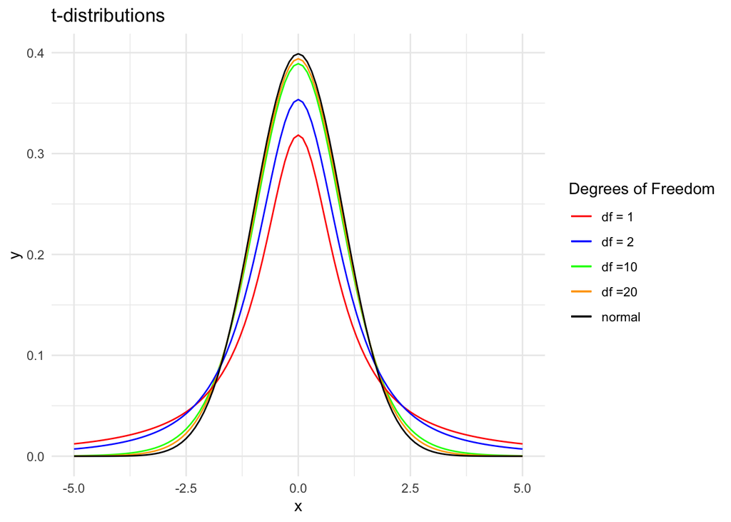

```r
df <- data.frame(x=seq(-5,5,.1))

ggplot(df, aes(x=x)) +
  stat_function(fun=dt, args = 10, aes(color="df =10")) +
  stat_function(fun=dt, args = 20,aes(color="df =20")) +
  stat_function(fun=dt, args = 1,aes(color="df = 1")) +
  stat_function(fun=dt, args = 2,aes(color="df = 2")) +
  stat_function(fun=dnorm, args = c(0,1),aes(color="normal")) +
  scale_color_manual("Degrees of Freedom", values = c("red", "blue", "green", "orange","black")) +
  theme_minimal() +
  labs(title = "t-distributions")
```

### Conditions

To use the $t$-distribution the same conditions need to be met:

- Independence
- Normality

## Population Proportion

#### Example

Suppose we want to estimate the percentage of adults in a large city that use facebook. Of five hundred randomly sampled adults $421$ say they use facebook. Compute a $90 \%$ confidence interval for the true proportion of adults in the city that use facebook.

### Conditions

- Independence
- Success-Failure
1. A study is conducted to analyze internet privacy for teens. A group of $50$ teens is randomly sampled and $7$ report clicking on links from unknown email addresses. Construct a $90 \%$ confidence interval for the true proportion of teens that click on links from unknown email addresses or explain what conditions prevent you from applying our methods.
2. A study is conducted to analyze internet privacy for teens. A group of $50$ teens is randomly sampled and $7$ report clicking on links from unknown email addresses. Construct a $90 \%$ confidence interval for the true proportion of teens that click on links from unknown email addresses or explain what conditions prevent you from applying our methods.
3. Suppose scores on a statistics exam are normally distributed with an unknown population mean and a population standard deviation of $3$ points. A random sample of $16$ scores is taken and gives a smample mean of $68$. Construct a $95 \%$ confidence interval for the true population mean or explain what conditions prevent you from applying our methods.
4. Suppose the distribution of average pizza delivery are skewed right with an unknown population mean and population standard deviation. A random sample of $128$ pizza delivery restaurants is taken and has a sample mean delivery time of $36$ minutes with a standard deviation of $8$ minutes. Construct a $95 \%$ confidence interval for the true population mean or explain what conditions prevent you from applying our methods.